# Economic Insecurity in Charlottesville, Virginia

An Analysis of ACS PUMS Data, 2018–2023

Taranpreet Kaur, Nathan Gregory, and Cole Leis

2026-04-30

# 1. Introduction

## Overview

Economic insecurity — the condition of lacking sufficient financial resources to meet basic needs or withstand unexpected hardships — remains a persistent challenge across the United States. In Charlottesville, Virginia, a city characterized by its university-driven economy and rapidly changing housing market, the dimensions of economic vulnerability take on distinct local patterns that warrant careful examination.

This report draws on American Community Survey (ACS) Public Use Microdata Sample (PUMS) data to investigate how economic insecurity has evolved in Charlottesville between 2018 and 2023, using 5-year estimates for each period. The analysis compares Charlottesville with Virginia as a whole, providing a broader context for understanding local conditions. By examining individual- and household-level indicators — poverty rates, employment patterns, health insurance coverage, public assistance participation, and housing cost burden — this report aims to paint a comprehensive picture of who is most affected by economic insecurity and how these patterns have shifted over time.

The central research questions guiding this exploration are:

1. How have poverty rates changed in Charlottesville between 2018 and 2023, and how does Charlottesville compare to Virginia overall?
2. Which demographic groups — defined by race, age, and education — face the greatest economic insecurity?
3. To what degree are households burdened by housing costs, and has this changed over time?
4. What share of residents lack health insurance coverage or rely on public assistance?

The analysis relies on person-level data (capturing individual demographics, employment, income, and insurance) and household-level data (capturing household income, housing costs, SNAP participation, and tenure). Survey weights (`PWGTP` for persons, `WGTP` for households) are applied throughout to produce population-representative estimates. Economic insecurity is defined as living at or below 200% of the Federal Poverty Level (FPL), while poverty is defined at or below 100% FPL.

The sections that follow proceed from data preparation and demographic profiling through to the main findings on employment, housing, and safety-net access, concluding with a discussion of limitations and directions for future research.

# 2. Data & Methods

## Load Libraries and Data

Before working with the ACS microdata, several R packages are loaded to support data wrangling, analysis, and presentation. The `tidyverse` provides tools for data manipulation and visualization. The `survey` package is essential for analyzing ACS data because the ACS is a complex survey dataset that includes sampling weights; incorporating these weights allows estimates to better represent the underlying population. The `scales` package formats numerical outputs (percentages, currency) for clearer interpretation, and `knitr` generates well-formatted tables.

```r
library(tidyverse)
library(survey)
library(scales)
library(knitr)
library(ggplot2)
```

The ACS PUMS datasets are organized into person-level files (containing individual characteristics such as age, race, employment status, income, and health insurance coverage) and household-level files (containing household income, housing costs, SNAP participation, and tenure). Separate datasets are loaded for Charlottesville and Virginia across the two ACS periods (2018 and 2023).

```r
# Person-level files
cvl_person_2018 <- read_csv("../data/cvl_acspums_person_5year_2018.csv")
cvl_person_2023 <- read_csv("../data/cvl_acspums_person_5year_2023.csv")
va_person_2018  <- read_csv("../data/va_acspums_person_5year_2018.csv")
va_person_2023  <- read_csv("../data/va_acspums_person_5year_2023.csv")

# Household-level files
cvl_hh_2018 <- read_csv("../data/cvl_acspums_household_5year_2018.csv")
cvl_hh_2023 <- read_csv("../data/cvl_acspums_household_5year_2023.csv")
va_hh_2018  <- read_csv("../data/va_acspums_household_5year_2018.csv")
va_hh_2023  <- read_csv("../data/va_acspums_household_5year_2023.csv")
```

## Consistent Definitions

To ensure comparability across all sections, consistent labels and thresholds are applied throughout. The poverty line is set at 100% FPL, and the economic insecurity threshold is set at 200% FPL. Labeling functions standardize the coding of race, education, employment status, housing tenure, insurance coverage, SNAP participation, and occupation categories.

```r
poverty_line <- 100
economic_insecurity_line <- 200

label_pov_group <- function(x) {
  case_when(
    is.na(x) ~ NA_character_,
    x <= poverty_line ~ "At or Below Poverty",
    x <= economic_insecurity_line ~ "Near Poverty",
    TRUE ~ "Above Poverty"
  )
}

label_esr <- function(x) {
  case_when(
    is.na(x) ~ NA_character_,
    as.character(x) == "1" ~ "Employed (civilian, at work)",
    as.character(x) == "2" ~ "Employed (civilian, not at work)",
    as.character(x) == "3" ~ "Unemployed",
    as.character(x) == "4" ~ "Armed forces, at work",
    as.character(x) == "5" ~ "Armed forces, not at work",
    as.character(x) == "6" ~ "Not in labor force",
    TRUE ~ "Other / unknown"
  )
}

label_labor_force <- function(x) {
  case_when(
    is.na(x) ~ NA_character_,
    as.character(x) %in% c("1", "2") ~ "Employed (civilian)",
    as.character(x) == "3" ~ "Unemployed",
    as.character(x) %in% c("4", "5") ~ "Armed forces",
    as.character(x) == "6" ~ "Not in labor force",
    TRUE ~ "Other / unknown"
  )
}

label_race <- function(x) {
  case_when(
    is.na(x) ~ NA_character_,
    as.character(x) == "1" ~ "White alone",
    as.character(x) == "2" ~ "Black or African American alone",
    as.character(x) %in% c("3", "4", "5") ~ "American Indian / Alaska Native",
    as.character(x) == "6" ~ "Asian alone",
    as.character(x) == "7" ~ "Native Hawaiian / Pacific Islander alone",
    as.character(x) == "8" ~ "Some Other Race alone",
    as.character(x) == "9" ~ "Two or More Races",
    TRUE ~ "Other / unknown"
  )
}

label_education <- function(x) {
  case_when(
    is.na(x) ~ NA_character_,
    as.numeric(x) <= 15 ~ "Less than high school",
    as.numeric(x) %in% c(16, 17) ~ "High school/GED",
    as.numeric(x) %in% c(18, 19) ~ "Some college, no degree",
    as.numeric(x) == 20 ~ "Associate's degree",
    as.numeric(x) == 21 ~ "Bachelor's degree",
    as.numeric(x) %in% c(22, 23, 24) ~ "Graduate/professional degree",
    TRUE ~ "Other / unknown"
  )
}

label_tenure <- function(x) {
  case_when(
    is.na(x) ~ NA_character_,
    as.character(x) == "1" ~ "Owner with mortgage",
    as.character(x) == "2" ~ "Owner free and clear",
    as.character(x) == "3" ~ "Renter",
    as.character(x) == "4" ~ "Occupied without paying rent",
    TRUE ~ "Other / unknown"
  )
}

label_snap <- function(x) {
  case_when(
    is.na(x) ~ NA_character_,
    as.character(x) == "1" ~ "SNAP recipient",
    as.character(x) == "2" ~ "No SNAP",
    TRUE ~ "Other / unknown"
  )
}

label_hicov <- function(x) {
  case_when(
    is.na(x) ~ NA_character_,
    as.character(x) == "1" ~ "Insured",
    as.character(x) == "2" ~ "Uninsured",
    TRUE ~ "Other / unknown"
  )
}

label_occ_group <- function(x) {
  occ_num <- suppressWarnings(as.numeric(as.character(x)))
  case_when(
    is.na(occ_num) ~ NA_character_,
    occ_num >= 10 & occ_num <= 440 ~ "Management",
    occ_num >= 500 & occ_num <= 960 ~ "Business and finance",
    occ_num >= 1005 & occ_num <= 1980 ~ "Computer, engineering, and science",
    occ_num >= 2001 & occ_num <= 2920 ~ "Community, legal, education, and arts",
    occ_num >= 3000 & occ_num <= 3550 ~ "Healthcare practitioners and technical",
    occ_num >= 3601 & occ_num <= 3655 ~ "Healthcare support",
    occ_num >= 3700 & occ_num <= 3960 ~ "Protective service",
    occ_num >= 4000 & occ_num <= 4160 ~ "Food preparation and serving",
    occ_num >= 4200 & occ_num <= 4655 ~ "Cleaning and personal service",
    occ_num >= 4700 & occ_num <= 5940 ~ "Sales and office",
    occ_num >= 6005 & occ_num <= 6130 ~ "Farming, fishing, and forestry",
    occ_num >= 6200 & occ_num <= 6950 ~ "Construction and extraction",
    occ_num >= 7000 & occ_num <= 7640 ~ "Installation, maintenance, and repair",
    occ_num >= 7700 & occ_num <= 8990 ~ "Production",
    occ_num >= 9005 & occ_num <= 9760 ~ "Transportation and material moving",
    occ_num >= 9800 & occ_num <= 9830 ~ "Military",
    occ_num == 9920 ~ "No recent work experience",
    TRUE ~ "Other / unknown"
  )
}
```

## Variable Selection and Data Preparation

The variables selected for person-level analysis capture demographics (age, sex, race, Hispanic origin), education, employment status, wages, public assistance income, poverty ratio, health insurance coverage, disability status, hours worked, and occupation. Household-level variables capture household size, tenure, SNAP participation, household and family income, gross rent, and housing cost burden ratios.

```r
person_vars <- c(
  "SERIALNO", "SPORDER", "PWGTP",
  "AGEP", "SEX", "RAC1P", "HISP",
  "SCHL", "ESR", "COW",
  "WAGP", "SSIP", "PAP",
  "POVPIP", "HICOV", "DIS", "WKHP", "OCCP"
)

prep_person <- function(df, year) {
  df %>%
    select(any_of(person_vars)) %>%
    mutate(year = year)
}

cvl_p18 <- prep_person(cvl_person_2018, 2018)
cvl_p23 <- prep_person(cvl_person_2023, 2023)
va_p18  <- prep_person(va_person_2018,  2018)
va_p23  <- prep_person(va_person_2023,  2023)
```

```r
hh_vars <- c(
  "SERIALNO", "WGTP", "NP", "TEN", "FS",
  "HINCP", "FINCP", "GRNTP", "GRPIP", "OCPIP", "HHL"
)

prep_hh <- function(df, year) {
  df %>%
    select(any_of(hh_vars)) %>%
    mutate(year = year)
}

cvl_h18 <- prep_hh(cvl_hh_2018, 2018)
cvl_h23 <- prep_hh(cvl_hh_2023, 2023)
va_h18  <- prep_hh(va_hh_2018,  2018)
va_h23  <- prep_hh(va_hh_2023,  2023)
```

```r
standardize_person <- function(df, year, geography) {
  df %>%
    mutate(
      PUMA = if ("PUMA" %in% names(.)) as.character(PUMA) else NA_character_,
      SERIALNO = as.character(SERIALNO),
      year = year,
      geography = geography
    )
}

standardize_hh <- function(df, year, geography) {
  df %>%
    mutate(
      PUMA = if ("PUMA" %in% names(.)) as.character(PUMA) else NA_character_,
      SERIALNO = as.character(SERIALNO),
      year = year,
      geography = geography
    )
}

cvl_person_2018 <- standardize_person(cvl_person_2018, 2018, "Charlottesville")
cvl_person_2023 <- standardize_person(cvl_person_2023, 2023, "Charlottesville")
va_person_2018  <- standardize_person(va_person_2018, 2018, "Virginia")
va_person_2023  <- standardize_person(va_person_2023, 2023, "Virginia")

cvl_hh_2018 <- standardize_hh(cvl_hh_2018, 2018, "Charlottesville")
cvl_hh_2023 <- standardize_hh(cvl_hh_2023, 2023, "Charlottesville")
va_hh_2018  <- standardize_hh(va_hh_2018, 2018, "Virginia")
va_hh_2023  <- standardize_hh(va_hh_2023, 2023, "Virginia")

# Combine all person and household files
all_per <- bind_rows(cvl_person_2018, cvl_person_2023, va_person_2018, va_person_2023)
all_hh  <- bind_rows(cvl_hh_2018, cvl_hh_2023, va_hh_2018, va_hh_2023)

# Define economic insecurity
all_per <- all_per %>%
  mutate(
    insecure = case_when(
      is.na(POVPIP) ~ NA,
      POVPIP <= economic_insecurity_line ~ TRUE,
      POVPIP > economic_insecurity_line  ~ FALSE
    ),
    insecurity_group = case_when(
      is.na(POVPIP) ~ "Missing",
      POVPIP <= poverty_line ~ "0-100% FPL",
      POVPIP <= economic_insecurity_line ~ "101-200% FPL",
      TRUE ~ ">200% FPL"
    )
  )

# Create demographic labels
all_per <- all_per %>%
  mutate(
    age_group = case_when(
      is.na(AGEP) ~ NA_character_,
      AGEP < 18 ~ "Under 18",
      AGEP < 25 ~ "18-24",
      AGEP < 45 ~ "25-44",
      AGEP < 65 ~ "45-64",
      TRUE ~ "65+"
    ),
    race_label = label_race(RAC1P),
    education_label = label_education(SCHL),
    labor_force_label = label_labor_force(ESR)
  )

all_hh <- all_hh %>%
  mutate(
    tenure_label = label_tenure(TEN),
    snap_label = label_snap(FS),
    hh_children_label = case_when(
      is.na(NOC) ~ NA_character_,
      NOC == 0 ~ "No own children",
      NOC == 1 ~ "1 child",
      NOC == 2 ~ "2 children",
      NOC >= 3 ~ "3+ children",
      TRUE ~ "Other / unknown"
    ),
    hh_size_label = case_when(
      is.na(NP) ~ NA_character_,
      NP == 1 ~ "1 person",
      NP == 2 ~ "2 people",
      NP == 3 ~ "3 people",
      NP == 4 ~ "4 people",
      NP >= 5 ~ "5+ people",
      TRUE ~ "Other / unknown"
    )
  )

# Merge person and household data
all_merged <- all_per %>%
  left_join(
    all_hh %>%
      select(any_of(c("SERIALNO", "year", "geography", "NP", "NOC", "TEN",
                      "RNTP", "GRNTP", "SMOCP", "HINCP", "FINCP", "FS",
                      "WGTP", "tenure_label", "snap_label",
                      "hh_children_label", "hh_size_label"))),
    by = c("SERIALNO", "year", "geography")
  )

# Prepare CVL-specific combined datasets for later sections
cvl_person_all <- bind_rows(cvl_p18, cvl_p23) %>% filter(!is.na(POVPIP))
cvl_hh_all     <- bind_rows(cvl_h18, cvl_h23)

cvl_person_ext <- bind_rows(
  cvl_person_2018 %>% mutate(year = 2018),
  cvl_person_2023 %>% mutate(year = 2023)
) %>%
  mutate(
    pov_group = label_pov_group(POVPIP),
    insecure = POVPIP <= economic_insecurity_line
  ) %>%
  filter(!is.na(pov_group))
```

# 3. Demographic Profile of Economic Insecurity

This section examines how economic insecurity is distributed across the population. Understanding which groups bear the heaviest burden is essential for identifying the structural factors that drive vulnerability and for targeting policy interventions effectively.

## Overall Prevalence

The table below presents the estimated share of the population living at or below 200% of the Federal Poverty Level — the threshold used throughout this report to define economic insecurity — for both Charlottesville and Virginia in 2018 and 2023.

```r
insecurity_summary <- all_per %>%
  filter(!is.na(insecure), !is.na(PWGTP)) %>%
  group_by(geography, year) %>%
  summarize(
    total_people = sum(PWGTP, na.rm = TRUE),
    insecure_people = sum(PWGTP[insecure], na.rm = TRUE),
    pct_insecure = insecure_people / total_people * 100,
    .groups = "drop"
  )

kable(insecurity_summary,
      digits = 1,
      col.names = c("Geography", "Year", "Total Population", "Insecure Population", "% Economically Insecure"),
      caption = "Estimated Share of People Living at or Below 200% FPL")
```

Estimated Share of People Living at or Below 200% FPL

| Geography | Year | Total Population | Insecure Population | % Economically Insecure |
| --- | --- | --- | --- | --- |
| Charlottesville | 2018 | 237333 | 65895 | 27.8 |
| Charlottesville | 2023 | 248568 | 57861 | 23.3 |
| Virginia | 2018 | 8162680 | 2081383 | 25.5 |
| Virginia | 2023 | 8411483 | 1980409 | 23.5 |

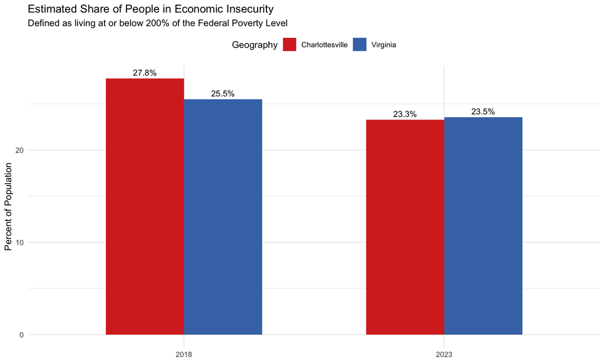

Comparison of economic insecurity rates between Charlottesville and Virginia, 2018 vs. 2023.

```r
insecurity_summary %>%
  ggplot(aes(x = factor(year), y = pct_insecure, fill = geography)) +
  geom_col(position = "dodge", width = 0.6) +
  geom_text(aes(label = paste0(round(pct_insecure, 1), "%")),
            position = position_dodge(width = 0.6), vjust = -0.5, size = 3.5) +
  scale_fill_manual(values = c("Charlottesville" = color_2023, "Virginia" = color_2018), name = "Geography") +
  labs(
    title = "Estimated Share of People in Economic Insecurity",
    subtitle = "Defined as living at or below 200% of the Federal Poverty Level",
    x = NULL, y = "Percent of Population"
  ) +
  theme_minimal() +
  theme(legend.position = "top")
```

## Poverty Bands

Breaking the population into finer poverty bands reveals where individuals cluster along the income spectrum. The three groups — at or below poverty (0–100% FPL), near poverty (101–200% FPL), and above poverty (>200% FPL) — help distinguish between deep poverty and the broader zone of economic vulnerability.

```r
poverty_bands <- all_per %>%
  filter(insecurity_group != "Missing", !is.na(PWGTP)) %>%
  group_by(geography, year, insecurity_group) %>%
  summarize(weighted_n = sum(PWGTP), .groups = "drop_last") %>%
  mutate(pct = weighted_n / sum(weighted_n) * 100) %>%
  ungroup()

kable(poverty_bands,
      digits = 1,
      col.names = c("Geography", "Year", "Poverty Band", "Weighted N", "% of Population"),
      caption = "Distribution Across Poverty Bands")
```

Distribution Across Poverty Bands

| Geography | Year | Poverty Band | Weighted N | % of Population |
| --- | --- | --- | --- | --- |
| Charlottesville | 2018 | 0-100% FPL | 31571 | 13.3 |
| Charlottesville | 2018 | 101-200% FPL | 34324 | 14.5 |
| Charlottesville | 2018 | >200% FPL | 171438 | 72.2 |
| Charlottesville | 2023 | 0-100% FPL | 28087 | 11.3 |
| Charlottesville | 2023 | 101-200% FPL | 29774 | 12.0 |
| Charlottesville | 2023 | >200% FPL | 190707 | 76.7 |
| Virginia | 2018 | 0-100% FPL | 907634 | 11.1 |
| Virginia | 2018 | 101-200% FPL | 1173749 | 14.4 |
| Virginia | 2018 | >200% FPL | 6081297 | 74.5 |
| Virginia | 2023 | 0-100% FPL | 851362 | 10.1 |
| Virginia | 2023 | 101-200% FPL | 1129047 | 13.4 |
| Virginia | 2023 | >200% FPL | 6431074 | 76.5 |

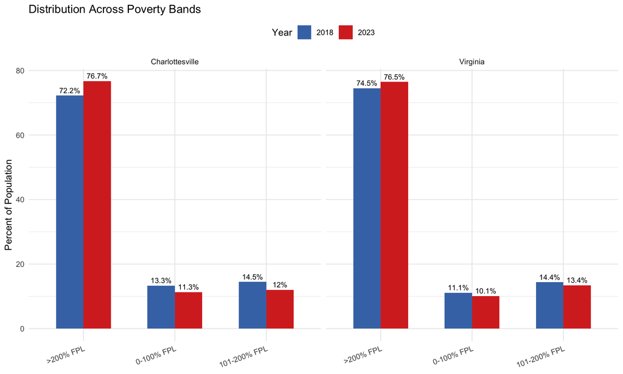

Distribution of the population across poverty bands in Charlottesville and Virginia.

```r
poverty_bands %>%
  ggplot(aes(x = insecurity_group, y = pct, fill = factor(year))) +
  geom_col(position = "dodge", width = 0.6) +
  geom_text(aes(label = paste0(round(pct, 1), "%")),
            position = position_dodge(width = 0.6), vjust = -0.5, size = 3) +
  facet_wrap(~ geography) +
  scale_fill_manual(values = c("2018" = color_2018, "2023" = color_2023), name = "Year") +
  labs(
    title = "Distribution Across Poverty Bands",
    x = NULL, y = "Percent of Population"
  ) +
  theme_minimal() +
  theme(legend.position = "top", axis.text.x = element_text(angle = 20, hjust = 1))
```

## CVL vs. Virginia: Poverty Rates

Comparing Charlottesville with statewide poverty rates helps place local conditions in a broader context. If poverty rates in Charlottesville differ substantially from those in Virginia overall, this may reflect local labor markets, housing costs, or demographic composition.

```r
all_person_2023 <- bind_rows(
  cvl_p23 %>% mutate(geo = "Charlottesville"),
  va_p23  %>% mutate(geo = "Virginia")
) %>%
  filter(!is.na(POVPIP))

cvl_va_compare <- all_person_2023 %>%
  group_by(geo) %>%
  summarise(
    pct_below_poverty = sum(PWGTP[POVPIP <= poverty_line], na.rm = TRUE) / sum(PWGTP) * 100,
    pct_near_poverty  = sum(PWGTP[POVPIP <= economic_insecurity_line], na.rm = TRUE) / sum(PWGTP) * 100
  )

kable(cvl_va_compare,
      digits = 1,
      col.names = c("Geography", "% At or Below Poverty", "% At or Below 200% FPL"),
      caption = "2023: Charlottesville vs. Virginia — Poverty Rates")
```

2023: Charlottesville vs. Virginia — Poverty Rates

| Geography | % At or Below Poverty | % At or Below 200% FPL |
| --- | --- | --- |
| Charlottesville | 11.3 | 23.3 |
| Virginia | 10.1 | 23.5 |

## By Age

Age is a critical dimension of economic insecurity. Young adults (18–24), many of whom are college students with limited earnings, and older adults (65+) living on fixed incomes may be disproportionately affected.

```r
age_summary <- all_per %>%
  filter(!is.na(insecure), !is.na(age_group), !is.na(PWGTP)) %>%
  mutate(age_group = factor(age_group, levels = c("Under 18", "18-24", "25-44", "45-64", "65+"))) %>%
  group_by(geography, year, age_group) %>%
  summarize(
    total = sum(PWGTP),
    insecure_total = sum(PWGTP[insecure]),
    pct_insecure = insecure_total / total * 100,
    .groups = "drop"
  )

kable(age_summary %>% select(geography, year, age_group, pct_insecure),
      digits = 1,
      col.names = c("Geography", "Year", "Age Group", "% Economically Insecure"),
      caption = "Economic Insecurity by Age Group")
```

Economic Insecurity by Age Group

| Geography | Year | Age Group | % Economically Insecure |
| --- | --- | --- | --- |
| Charlottesville | 2018 | Under 18 | 30.5 |
| Charlottesville | 2018 | 18-24 | 54.2 |
| Charlottesville | 2018 | 25-44 | 27.4 |
| Charlottesville | 2018 | 45-64 | 21.4 |
| Charlottesville | 2018 | 65+ | 21.9 |
| Charlottesville | 2023 | Under 18 | 26.1 |
| Charlottesville | 2023 | 18-24 | 43.1 |
| Charlottesville | 2023 | 25-44 | 23.0 |
| Charlottesville | 2023 | 45-64 | 16.6 |
| Charlottesville | 2023 | 65+ | 21.4 |
| Virginia | 2018 | Under 18 | 32.4 |
| Virginia | 2018 | 18-24 | 37.5 |
| Virginia | 2018 | 25-44 | 23.8 |
| Virginia | 2018 | 45-64 | 18.6 |
| Virginia | 2018 | 65+ | 23.9 |
| Virginia | 2023 | Under 18 | 30.2 |
| Virginia | 2023 | 18-24 | 32.9 |
| Virginia | 2023 | 25-44 | 21.5 |
| Virginia | 2023 | 45-64 | 17.3 |
| Virginia | 2023 | 65+ | 23.3 |

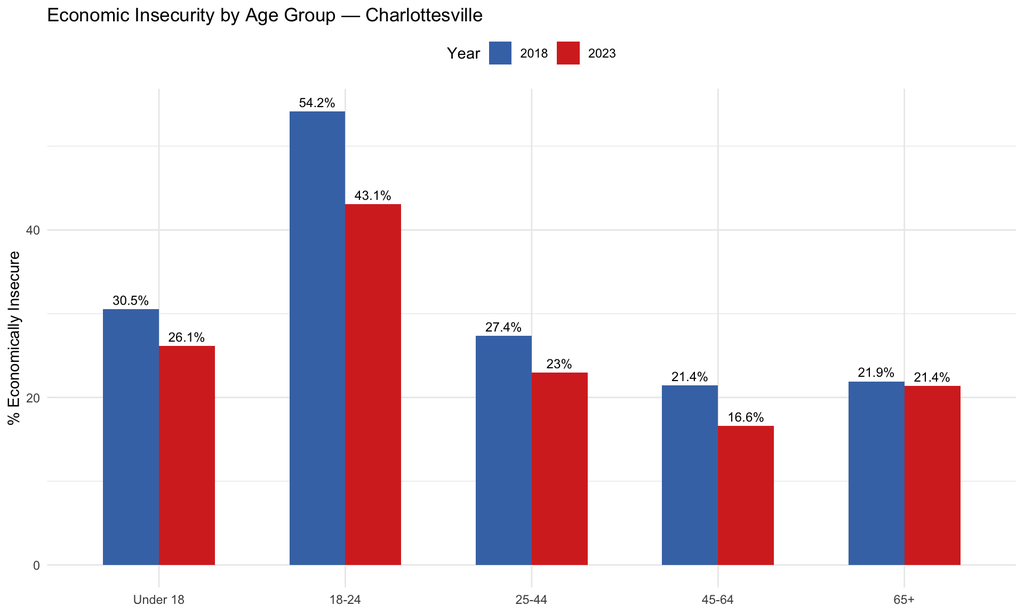

Economic insecurity rates by age group across 2018 and 2023.

```r
age_summary %>%
  filter(geography == "Charlottesville") %>%
  ggplot(aes(x = age_group, y = pct_insecure, fill = factor(year))) +
  geom_col(position = "dodge", width = 0.6) +
  geom_text(aes(label = paste0(round(pct_insecure, 1), "%")),
            position = position_dodge(width = 0.6), vjust = -0.5, size = 3.2) +
  scale_fill_manual(values = c("2018" = color_2018, "2023" = color_2023), name = "Year") +
  labs(
    title = "Economic Insecurity by Age Group — Charlottesville",
    x = NULL, y = "% Economically Insecure"
  ) +
  theme_minimal() +
  theme(legend.position = "top")
```

## By Race

Racial disparities in economic outcomes are well-documented nationally. This section examines whether similar patterns are present in Charlottesville and how they compare to statewide figures.

```r
race_summary <- all_per %>%
  filter(!is.na(insecure), !is.na(race_label), !is.na(PWGTP)) %>%
  group_by(geography, year, race_label) %>%
  summarize(
    total = sum(PWGTP),
    insecure_total = sum(PWGTP[insecure]),
    pct_insecure = insecure_total / total * 100,
    .groups = "drop"
  )

kable(race_summary %>% filter(geography == "Charlottesville") %>% select(year, race_label, total, pct_insecure),
      digits = 1,
      col.names = c("Year", "Race", "Population (Weighted)", "% Economically Insecure"),
      caption = "Economic Insecurity by Race — Charlottesville")
```

Economic Insecurity by Race — Charlottesville

| Year | Race | Population (Weighted) | % Economically Insecure |
| --- | --- | --- | --- |
| 2018 | American Indian / Alaska Native | 567 | 64.9 |
| 2018 | Asian alone | 8233 | 40.8 |
| 2018 | Black or African American alone | 29710 | 45.9 |
| 2018 | Native Hawaiian / Pacific Islander alone | 39 | 23.1 |
| 2018 | Some Other Race alone | 2688 | 70.0 |
| 2018 | Two or More Races | 5549 | 32.2 |
| 2018 | White alone | 190547 | 23.5 |
| 2023 | American Indian / Alaska Native | 407 | 40.5 |
| 2023 | Asian alone | 8787 | 35.3 |
| 2023 | Black or African American alone | 27433 | 42.2 |
| 2023 | Native Hawaiian / Pacific Islander alone | 79 | 0.0 |
| 2023 | Some Other Race alone | 6180 | 51.6 |
| 2023 | Two or More Races | 15519 | 29.3 |
| 2023 | White alone | 190163 | 18.6 |

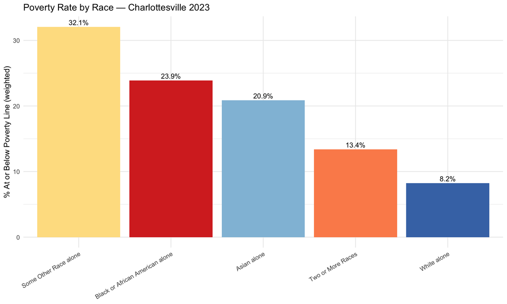

Poverty rate by racial group in Charlottesville, 2023.

```r
cvl_p23 %>%
  filter(!is.na(POVPIP), !is.na(RAC1P)) %>%
  mutate(race = label_race(RAC1P),
         in_poverty = POVPIP <= poverty_line) %>%
  group_by(race) %>%
  summarise(
    total = sum(PWGTP, na.rm = TRUE),
    poor  = sum(PWGTP[in_poverty], na.rm = TRUE),
    pct   = poor / total * 100
  ) %>%
  filter(total > 500) %>%
  ggplot(aes(x = reorder(race, -pct), y = pct, fill = race)) +
  geom_col(show.legend = FALSE) +
  geom_text(aes(label = paste0(round(pct, 1), "%")), vjust = -0.4, size = 3.5) +
  scale_fill_manual(values = c(
    "White alone" = color_2018,
    "Black or African American alone" = color_2023,
    "Asian alone" = "#91BFDB",
    "Two or More Races" = "#FC8D59",
    "Some Other Race alone" = "#FEE090",
    "American Indian / Alaska Native" = "#ABD9E9",
    "Native Hawaiian / Pacific Islander alone" = "#FDAE61"
  )) +
  labs(
    title = "Poverty Rate by Race — Charlottesville 2023",
    x = NULL, y = "% At or Below Poverty Line (weighted)"
  ) +
  theme_minimal() +
  theme(axis.text.x = element_text(angle = 30, hjust = 1))
```

## By Education

Education is one of the strongest predictors of economic outcomes. Higher educational attainment is generally associated with greater earnings potential and more stable employment. This section examines how insecurity rates vary by education level among adults aged 25 and older.

```r
edu_summary <- all_per %>%
  filter(!is.na(insecure), !is.na(education_label), !is.na(PWGTP), AGEP >= 25) %>%
  group_by(geography, year, education_label) %>%
  summarize(
    total = sum(PWGTP),
    insecure_total = sum(PWGTP[insecure]),
    pct_insecure = insecure_total / total * 100,
    .groups = "drop"
  )

kable(edu_summary %>% filter(geography == "Charlottesville") %>% select(year, education_label, pct_insecure),
      digits = 1,
      col.names = c("Year", "Education Level", "% Economically Insecure"),
      caption = "Economic Insecurity by Education Level — Charlottesville (Ages 25+)")
```

Economic Insecurity by Education Level — Charlottesville (Ages 25+)

| Year | Education Level | % Economically Insecure |
| --- | --- | --- |
| 2018 | Associate’s degree | 19.9 |
| 2018 | Bachelor’s degree | 15.2 |
| 2018 | Graduate/professional degree | 9.1 |
| 2018 | High school/GED | 32.4 |
| 2018 | Less than high school | 54.8 |
| 2018 | Some college, no degree | 24.4 |
| 2023 | Associate’s degree | 18.4 |
| 2023 | Bachelor’s degree | 11.0 |
| 2023 | Graduate/professional degree | 7.8 |
| 2023 | High school/GED | 30.8 |
| 2023 | Less than high school | 54.0 |
| 2023 | Some college, no degree | 24.7 |

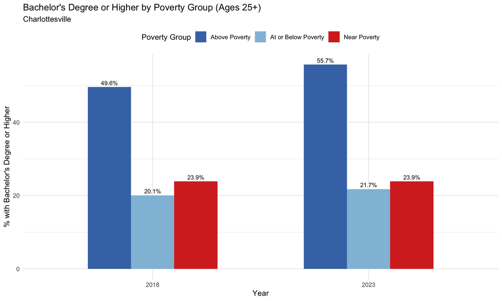

Share with a bachelor’s degree or higher by poverty group, Charlottesville.

```r
education_summary_ext <- cvl_person_ext %>%
  filter(AGEP >= 25, !is.na(SCHL)) %>%
  group_by(year, pov_group) %>%
  summarise(
    pct_bachelors_or_higher =
      sum(PWGTP * (as.numeric(SCHL) >= 21), na.rm = TRUE) /
      sum(PWGTP, na.rm = TRUE) * 100,
    .groups = "drop"
  )

ggplot(education_summary_ext,
       aes(x = factor(year), y = pct_bachelors_or_higher, fill = pov_group)) +
  geom_col(position = "dodge", width = 0.6) +
  geom_text(aes(label = paste0(round(pct_bachelors_or_higher, 1), "%")),
            position = position_dodge(width = 0.6), vjust = -0.5, size = 3) +
  scale_fill_manual(values = palette_main, name = "Poverty Group") +
  labs(
    title = "Bachelor's Degree or Higher by Poverty Group (Ages 25+)",
    subtitle = "Charlottesville",
    x = "Year", y = "% with Bachelor's Degree or Higher"
  ) +
  theme_minimal() +
  theme(legend.position = "top")
```

## Poverty Income Distribution

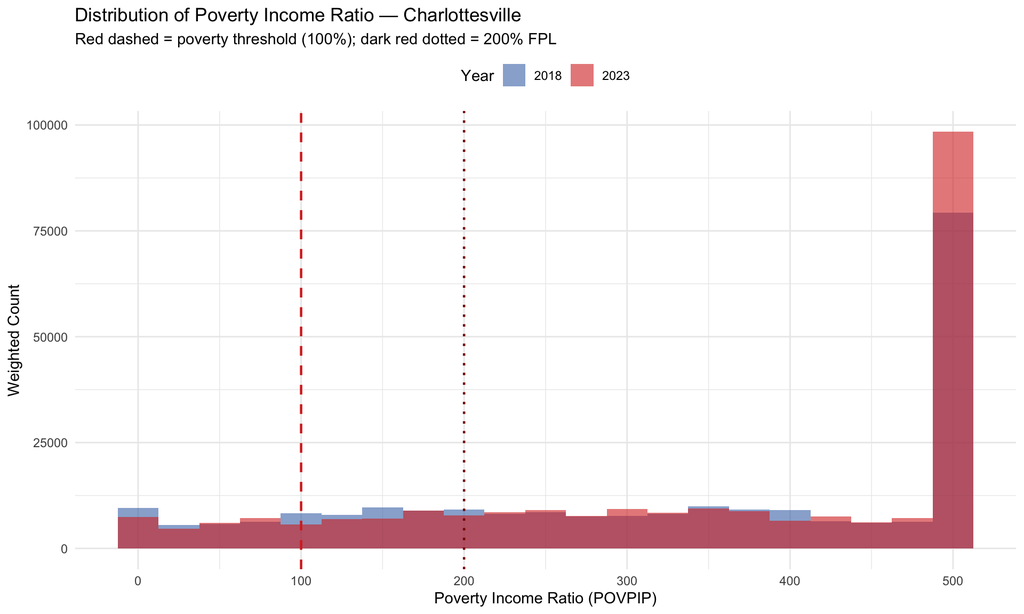

Distribution of poverty income ratio in Charlottesville, 2018 vs. 2023.

```r
cvl_person_all %>%
  filter(POVPIP <= 501) %>%
  ggplot(aes(x = POVPIP, weight = PWGTP, fill = factor(year))) +
  geom_histogram(binwidth = 25, position = "identity", alpha = 0.6) +
  geom_vline(xintercept = 100, linetype = "dashed", color = color_2023, linewidth = 0.8) +
  geom_vline(xintercept = 200, linetype = "dotted", color = "darkred", linewidth = 0.8) +
  scale_fill_manual(values = c("2018" = color_2018, "2023" = color_2023), name = "Year") +
  scale_x_continuous(breaks = seq(0, 500, 100)) +
  labs(
    title = "Distribution of Poverty Income Ratio — Charlottesville",
    subtitle = "Red dashed = poverty threshold (100%); dark red dotted = 200% FPL",
    x = "Poverty Income Ratio (POVPIP)", y = "Weighted Count"
  ) +
  theme_minimal() +
  theme(legend.position = "top")
```

# 4. Main Findings

This section presents the central findings of the analysis, organized around three key domains of economic insecurity: employment and labor market participation, housing affordability, and access to safety-net programs. Each domain is explored through tables and visualizations that compare patterns across years, poverty groups, and geographies.

## Employment

### Employment Status

Employment is a fundamental determinant of economic security. Stable employment provides income, benefits, and a pathway to financial stability, while unemployment or detachment from the labor force increases vulnerability. The following analysis examines how employment status has changed in Charlottesville between 2018 and 2023.

```r
emp_status <- cvl_person_all %>%
  filter(!is.na(ESR), AGEP >= 16) %>%
  mutate(ESR_label = label_esr(ESR)) %>%
  group_by(year, ESR_label) %>%
  summarise(weighted_n = sum(PWGTP, na.rm = TRUE), .groups = "drop") %>%
  group_by(year) %>%
  mutate(pct = weighted_n / sum(weighted_n) * 100) %>%
  ungroup()

kable(emp_status %>% select(year, ESR_label, weighted_n, pct),
      digits = 1,
      col.names = c("Year", "Employment Status", "Weighted Count", "% of Population"),
      caption = "Employment Status Distribution — Charlottesville (Adults 16+)")
```

Employment Status Distribution — Charlottesville (Adults 16+)

| Year | Employment Status | Weighted Count | % of Population |
| --- | --- | --- | --- |
| 2018 | Armed forces, at work | 585 | 0.3 |
| 2018 | Employed (civilian, at work) | 117760 | 60.7 |
| 2018 | Employed (civilian, not at work) | 1972 | 1.0 |
| 2018 | Not in labor force | 69180 | 35.7 |
| 2018 | Unemployed | 4534 | 2.3 |
| 2023 | Armed forces, at work | 584 | 0.3 |
| 2023 | Employed (civilian, at work) | 124518 | 61.0 |
| 2023 | Employed (civilian, not at work) | 2562 | 1.3 |
| 2023 | Not in labor force | 72089 | 35.3 |
| 2023 | Unemployed | 4396 | 2.2 |

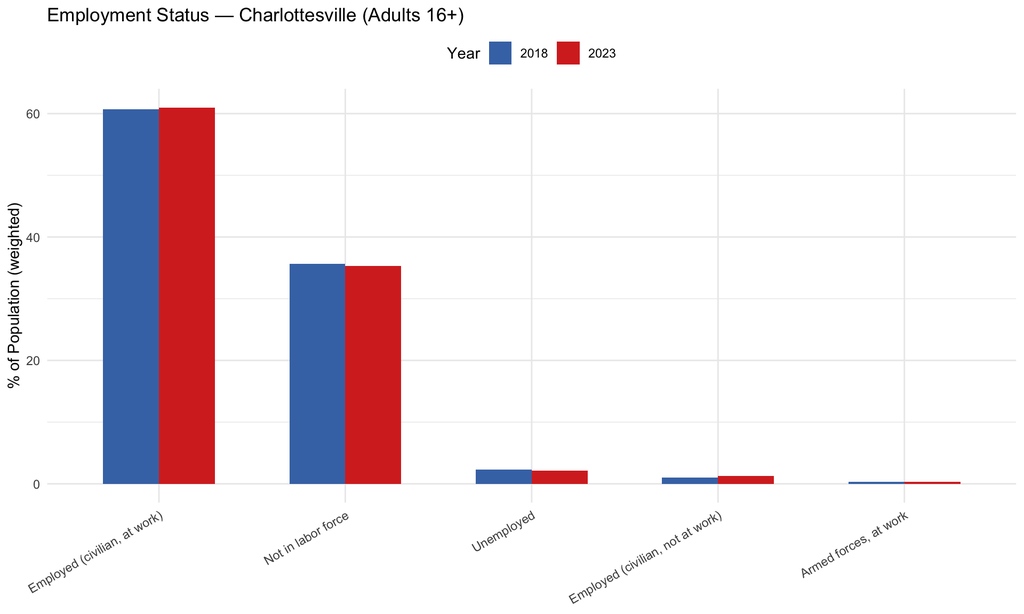

Employment status distribution for Charlottesville adults, 2018 vs. 2023.

```r
emp_status %>%
  ggplot(aes(x = reorder(ESR_label, -pct), y = pct, fill = factor(year))) +
  geom_col(position = "dodge", width = 0.6) +
  scale_fill_manual(values = c("2018" = color_2018, "2023" = color_2023), name = "Year") +
  labs(
    title = "Employment Status — Charlottesville (Adults 16+)",
    x = NULL, y = "% of Population (weighted)"
  ) +
  theme_minimal() +
  theme(axis.text.x = element_text(angle = 30, hjust = 1), legend.position = "top")
```

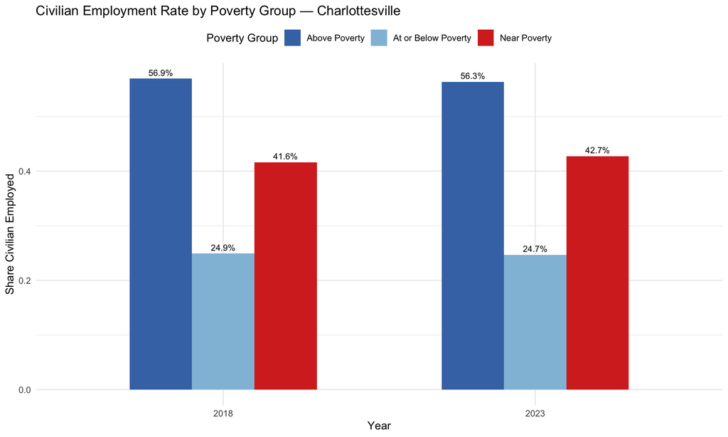

Civilian employment rate by poverty group in Charlottesville.

```r
employment_summary_ext <- cvl_person_ext %>%
  group_by(year, pov_group) %>%
  summarise(
    civilian_employment_rate =
      sum(PWGTP * (as.character(ESR) %in% c("1", "2")), na.rm = TRUE) /
      sum(PWGTP, na.rm = TRUE),
    .groups = "drop"
  )

ggplot(employment_summary_ext,
       aes(x = factor(year), y = civilian_employment_rate, fill = pov_group)) +
  geom_col(position = "dodge", width = 0.6) +
  geom_text(aes(label = paste0(round(civilian_employment_rate * 100, 1), "%")),
            position = position_dodge(width = 0.6), vjust = -0.5, size = 3) +
  scale_fill_manual(values = palette_main, name = "Poverty Group") +
  labs(
    title = "Civilian Employment Rate by Poverty Group — Charlottesville",
    x = "Year", y = "Share Civilian Employed"
  ) +
  theme_minimal() +
  theme(legend.position = "top")
```

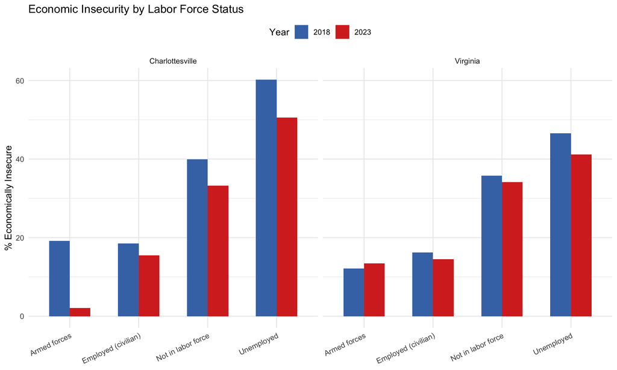

Economic insecurity by labor force status across Charlottesville and Virginia.

```r
employment_summary_geo <- all_per %>%
  filter(!is.na(insecure), !is.na(labor_force_label), !is.na(PWGTP)) %>%
  group_by(geography, year, labor_force_label) %>%
  summarize(
    total = sum(PWGTP),
    insecure_total = sum(PWGTP[insecure]),
    pct_insecure = insecure_total / total * 100,
    .groups = "drop"
  )

employment_summary_geo %>%
  ggplot(aes(x = labor_force_label, y = pct_insecure, fill = factor(year))) +
  geom_col(position = "dodge", width = 0.6) +
  facet_wrap(~ geography) +
  scale_fill_manual(values = c("2018" = color_2018, "2023" = color_2023), name = "Year") +
  labs(
    title = "Economic Insecurity by Labor Force Status",
    x = NULL, y = "% Economically Insecure", fill = "Year"
  ) +
  theme_minimal() +
  theme(axis.text.x = element_text(angle = 25, hjust = 1), legend.position = "top")
```

### Hours Worked

Even among those who are employed, the number of hours worked per week varies considerably. Individuals in poverty or near-poverty may be underemployed — working fewer hours than desired — which limits their earnings potential and contributes to economic insecurity.

```r
hours_summary_ext <- cvl_person_ext %>%
  group_by(year, pov_group) %>%
  summarise(
    avg_hours = weighted.mean(WKHP, PWGTP, na.rm = TRUE),
    .groups = "drop"
  )

kable(hours_summary_ext,
      digits = 1,
      col.names = c("Year", "Poverty Group", "Avg. Weekly Hours"),
      caption = "Average Hours Worked per Week by Poverty Group — Charlottesville")
```

Average Hours Worked per Week by Poverty Group — Charlottesville

| Year | Poverty Group | Avg. Weekly Hours |
| --- | --- | --- |
| 2018 | Above Poverty | 39.6 |
| 2018 | At or Below Poverty | 28.1 |
| 2018 | Near Poverty | 35.2 |
| 2023 | Above Poverty | 39.4 |
| 2023 | At or Below Poverty | 29.1 |
| 2023 | Near Poverty | 36.1 |

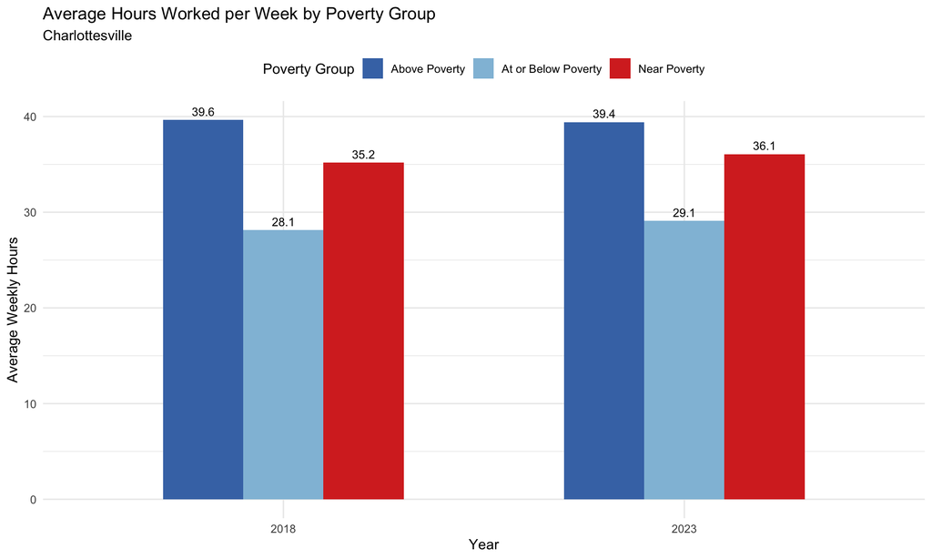

Average weekly hours worked by poverty group in Charlottesville.

```r
ggplot(hours_summary_ext,
       aes(x = factor(year), y = avg_hours, fill = pov_group)) +
  geom_col(position = "dodge", width = 0.6) +
  geom_text(aes(label = round(avg_hours, 1)),
            position = position_dodge(width = 0.6), vjust = -0.5, size = 3.2) +
  scale_fill_manual(values = palette_main, name = "Poverty Group") +
  labs(
    title = "Average Hours Worked per Week by Poverty Group",
    subtitle = "Charlottesville",
    x = "Year", y = "Average Weekly Hours"
  ) +
  theme_minimal() +
  theme(legend.position = "top")
```

```r
hours_geo <- all_per %>%
  filter(insecure == TRUE, !is.na(WKHP), !is.na(PWGTP)) %>%
  group_by(geography, year) %>%
  summarize(
    avg_hours = weighted.mean(WKHP, w = PWGTP, na.rm = TRUE),
    .groups = "drop"
  )

kable(hours_geo,
      digits = 1,
      col.names = c("Geography", "Year", "Avg. Weekly Hours (Insecure Pop.)"),
      caption = "Average Weekly Hours Among Economically Insecure Workers")
```

Average Weekly Hours Among Economically Insecure Workers

| Geography | Year | Avg. Weekly Hours (Insecure Pop.) |
| --- | --- | --- |
| Charlottesville | 2018 | 32.2 |
| Charlottesville | 2023 | 33.2 |
| Virginia | 2018 | 34.0 |
| Virginia | 2023 | 33.7 |

### Wages

Wage levels provide another window into how economic resources are distributed across poverty groups. Even among individuals who are employed, wage disparities can be substantial.

```r
wage_summary_ext <- cvl_person_ext %>%
  group_by(year, pov_group) %>%
  summarise(
    avg_wage = weighted.mean(WAGP, PWGTP, na.rm = TRUE),
    .groups = "drop"
  )

kable(wage_summary_ext,
      digits = 0,
      col.names = c("Year", "Poverty Group", "Avg. Wage ($)"),
      caption = "Average Wages by Poverty Group — Charlottesville")
```

Average Wages by Poverty Group — Charlottesville

| Year | Poverty Group | Avg. Wage ($) |
| --- | --- | --- |
| 2018 | Above Poverty | 41298 |
| 2018 | At or Below Poverty | 2516 |
| 2018 | Near Poverty | 9792 |
| 2023 | Above Poverty | 48179 |
| 2023 | At or Below Poverty | 3519 |
| 2023 | Near Poverty | 11254 |

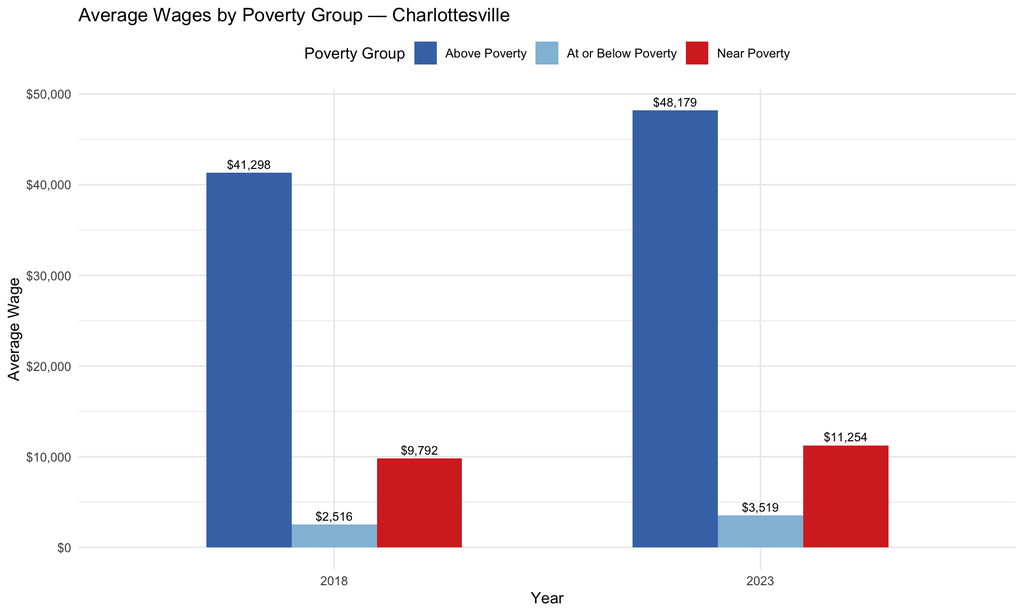

Average wages by poverty group in Charlottesville, 2018 vs. 2023.

```r
ggplot(wage_summary_ext,
       aes(x = factor(year), y = avg_wage, fill = pov_group)) +
  geom_col(position = "dodge", width = 0.6) +
  geom_text(aes(label = dollar(avg_wage, accuracy = 1)),
            position = position_dodge(width = 0.6), vjust = -0.5, size = 3) +
  scale_fill_manual(values = palette_main, name = "Poverty Group") +
  scale_y_continuous(labels = dollar_format()) +
  labs(
    title = "Average Wages by Poverty Group — Charlottesville",
    x = "Year", y = "Average Wage"
  ) +
  theme_minimal() +
  theme(legend.position = "top")
```

### Occupations

Understanding which occupations are most common among individuals in poverty provides insight into the types of jobs that may not offer sufficient wages or hours to lift workers above the poverty line.

```r
cvl_2023_occ <- cvl_person_2023 %>%
  mutate(
    pov_group = label_pov_group(POVPIP),
    occ_category = label_occ_group(OCCP)
  )

top_occ <- cvl_2023_occ %>%
  filter(pov_group == "At or Below Poverty", as.character(ESR) %in% c("1", "2")) %>%
  group_by(occ_category) %>%
  summarise(workers = sum(PWGTP), .groups = "drop") %>%
  arrange(desc(workers)) %>%
  slice_head(n = 8)

kable(top_occ,
      col.names = c("Occupation Category", "Weighted Workers in Poverty"),
      caption = "Most Common Occupations Among Workers in Poverty — Charlottesville 2023")
```

Most Common Occupations Among Workers in Poverty — Charlottesville 2023

| Occupation Category | Weighted Workers in Poverty |
| --- | --- |
| Food preparation and serving | 1144 |
| Sales and office | 1016 |
| Community, legal, education, and arts | 1006 |
| Cleaning and personal service | 803 |
| Transportation and material moving | 486 |
| Management | 456 |
| Healthcare support | 427 |
| Construction and extraction | 414 |

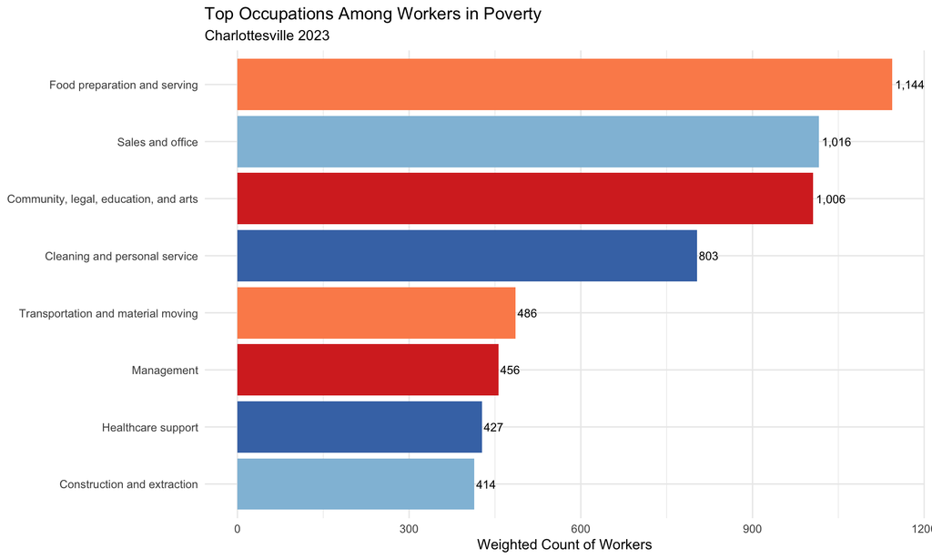

Top occupations among workers living in poverty in Charlottesville, 2023.

```r
top_occ %>%
  ggplot(aes(x = reorder(occ_category, workers), y = workers, fill = occ_category)) +
  geom_col(show.legend = FALSE) +
  geom_text(aes(label = comma(workers)), hjust = -0.1, size = 3.2) +
  scale_fill_manual(values = rep(c(color_2018, color_2023, "#91BFDB", "#FC8D59"), 3)) +
  coord_flip() +
  labs(
    title = "Top Occupations Among Workers in Poverty",
    subtitle = "Charlottesville 2023",
    x = NULL, y = "Weighted Count of Workers"
  ) +
  theme_minimal()
```

### Health Insurance

Access to health insurance is a vital indicator of economic security. Individuals without coverage face greater financial risk in the event of illness and may lack access to preventive care. Virginia’s Medicaid expansion, which took effect in 2019, may have significantly altered coverage patterns between the two study periods.

#### Coverage Over Time

```r
hi_table <- cvl_person_all %>%
  filter(!is.na(HICOV)) %>%
  mutate(insured = label_hicov(HICOV)) %>%
  group_by(year, insured) %>%
  summarise(weighted_n = sum(PWGTP, na.rm = TRUE), .groups = "drop") %>%
  group_by(year) %>%
  mutate(pct = weighted_n / sum(weighted_n) * 100) %>%
  ungroup()

kable(hi_table,
      digits = 1,
      col.names = c("Year", "Coverage Status", "Weighted N", "% of Population"),
      caption = "Charlottesville: Health Insurance Coverage")
```

Charlottesville: Health Insurance Coverage

| Year | Coverage Status | Weighted N | % of Population |
| --- | --- | --- | --- |
| 2018 | Insured | 215978 | 91.0 |
| 2018 | Uninsured | 21355 | 9.0 |
| 2023 | Insured | 232716 | 93.6 |
| 2023 | Uninsured | 15852 | 6.4 |

#### By Poverty Group

```r
hi_poverty <- cvl_person_ext %>%
  filter(!is.na(pov_group), !is.na(HICOV)) %>%
  mutate(insurance_status = label_hicov(HICOV)) %>%
  group_by(year, pov_group) %>%
  summarise(
    pct_uninsured =
      sum(PWGTP[insurance_status == "Uninsured"], na.rm = TRUE) /
      sum(PWGTP) * 100,
    .groups = "drop"
  )

kable(hi_poverty,
      digits = 1,
      col.names = c("Year", "Poverty Group", "% Uninsured"),
      caption = "Uninsured Rate by Poverty Group and Year — Charlottesville (Weighted)")
```

Uninsured Rate by Poverty Group and Year — Charlottesville (Weighted)

| Year | Poverty Group | % Uninsured |
| --- | --- | --- |
| 2018 | Above Poverty | 4.9 |
| 2018 | At or Below Poverty | 21.8 |
| 2018 | Near Poverty | 17.5 |
| 2023 | Above Poverty | 4.4 |
| 2023 | At or Below Poverty | 10.2 |
| 2023 | Near Poverty | 15.5 |

```r
hi_pov_2023 <- cvl_2023_occ %>%
  filter(!is.na(pov_group), !is.na(HICOV)) %>%
  mutate(insurance_status = label_hicov(HICOV)) %>%
  group_by(pov_group) %>%
  summarise(
    pct_uninsured =
      sum(PWGTP[insurance_status == "Uninsured"], na.rm = TRUE) /
      sum(PWGTP) * 100,
    .groups = "drop"
  )

kable(hi_pov_2023,
      digits = 1,
      col.names = c("Poverty Group", "% Uninsured"),
      caption = "Health Insurance by Poverty Group — Charlottesville 2023 (Weighted)")
```

Health Insurance by Poverty Group — Charlottesville 2023 (Weighted)

| Poverty Group | % Uninsured |
| --- | --- |
| Above Poverty | 4.4 |
| At or Below Poverty | 10.2 |
| Near Poverty | 15.5 |

### Public Assistance

Public assistance programs such as Supplemental Security Income (SSI), cash public assistance (PAP), and SNAP provide crucial support to individuals and households with limited income. Examining the share of residents who receive these forms of assistance helps gauge the extent to which the safety net is reaching those in need.

#### SSI & Cash Assistance

```r
pa_table <- cvl_person_all %>%
  group_by(year) %>%
  summarise(
    pct_pap  = sum(PWGTP[!is.na(PAP)  & PAP  > 0], na.rm = TRUE) / sum(PWGTP) * 100,
    pct_ssip = sum(PWGTP[!is.na(SSIP) & SSIP > 0], na.rm = TRUE) / sum(PWGTP) * 100
  )

kable(pa_table,
      digits = 2,
      col.names = c("Year", "% Receiving Public Assistance", "% Receiving SSI"),
      caption = "Charlottesville: Public Assistance & SSI Receipt")
```

Charlottesville: Public Assistance & SSI Receipt

| Year | % Receiving Public Assistance | % Receiving SSI |
| --- | --- | --- |
| 2018 | 0.82 | 2.00 |
| 2023 | 0.76 | 1.54 |

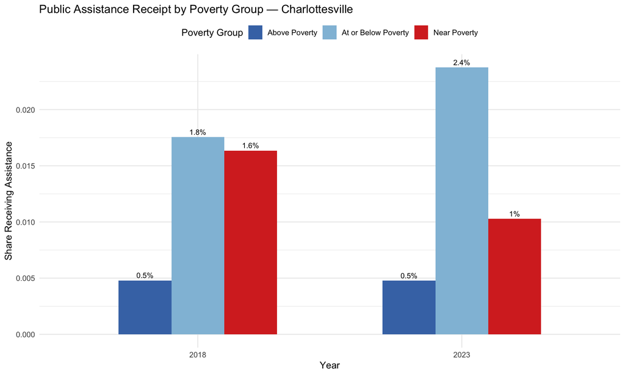

Public assistance receipt rates by poverty group in Charlottesville.

```r
assistance_summary_ext <- cvl_person_ext %>%
  group_by(year, pov_group) %>%
  summarise(
    pap_rate =
      sum(PWGTP * (PAP > 0), na.rm = TRUE) /
      sum(PWGTP, na.rm = TRUE),
    .groups = "drop"
  )

ggplot(assistance_summary_ext,
       aes(x = factor(year), y = pap_rate, fill = pov_group)) +
  geom_col(position = "dodge", width = 0.6) +
  geom_text(aes(label = paste0(round(pap_rate * 100, 1), "%")),
            position = position_dodge(width = 0.6), vjust = -0.5, size = 3) +
  scale_fill_manual(values = palette_main, name = "Poverty Group") +
  labs(
    title = "Public Assistance Receipt by Poverty Group — Charlottesville",
    x = "Year", y = "Share Receiving Assistance"
  ) +
  theme_minimal() +
  theme(legend.position = "top")
```

#### Household Size & Insecurity

Economic insecurity may also vary with household composition. Larger households may have more earners but also more dependents, while single-person households bear costs alone.

```r
hhsize_summary <- all_merged %>%
  filter(!is.na(insecure), !is.na(hh_size_label), !is.na(PWGTP)) %>%
  mutate(hh_size_label = factor(hh_size_label, levels = c("1 person", "2 people", "3 people", "4 people", "5+ people"))) %>%
  group_by(geography, year, hh_size_label) %>%
  summarize(
    total_people = sum(PWGTP),
    insecure_people = sum(PWGTP[insecure]),
    pct_insecure = insecure_people / total_people * 100,
    .groups = "drop"
  )

kable(hhsize_summary %>% filter(geography == "Charlottesville") %>% select(year, hh_size_label, pct_insecure),
      digits = 1,
      col.names = c("Year", "Household Size", "% Economically Insecure"),
      caption = "Economic Insecurity by Household Size — Charlottesville")
```

Economic Insecurity by Household Size — Charlottesville

| Year | Household Size | % Economically Insecure |
| --- | --- | --- |
| 2018 | 1 person | 37.2 |
| 2018 | 2 people | 20.9 |
| 2018 | 3 people | 27.0 |
| 2018 | 4 people | 27.1 |
| 2018 | 5+ people | 35.7 |
| 2023 | 1 person | 35.8 |
| 2023 | 2 people | 18.9 |
| 2023 | 3 people | 18.0 |
| 2023 | 4 people | 20.8 |
| 2023 | 5+ people | 30.7 |

## Housing

Housing affordability is one of the most visible and impactful dimensions of economic insecurity. Households that spend a disproportionate share of their income on housing have fewer resources available for food, healthcare, transportation, and savings. This section examines multiple facets of the housing landscape in Charlottesville.

### Household Income

```r
cvl_hh_income <- cvl_hh_all %>%
  filter(!is.na(HINCP), HINCP > 0)

hh_income_table <- cvl_hh_income %>%
  group_by(year) %>%
  summarise(
    weighted_median = median(rep(HINCP, WGTP), na.rm = TRUE),
    weighted_mean   = sum(HINCP * WGTP, na.rm = TRUE) / sum(WGTP, na.rm = TRUE)
  ) %>%
  mutate(across(c(weighted_median, weighted_mean), dollar))

kable(hh_income_table,
      col.names = c("Year", "Weighted Median HH Income", "Weighted Mean HH Income"),
      caption = "Charlottesville: Household Income Summary")
```

Charlottesville: Household Income Summary

| Year | Weighted Median HH Income | Weighted Mean HH Income |
| --- | --- | --- |
| 2018 | $65,200 | $91,452 |
| 2023 | $80,100 | $110,153 |

### Housing Cost Burden

Households are considered “cost burdened” if they spend more than 30% of income on housing and “severely cost burdened” at 50% or more. The table below shows these rates for renters and owners separately.

```r
renter_burden <- bind_rows(cvl_h18, cvl_h23) %>%
  filter(!is.na(GRPIP), GRPIP > 0, TEN == 3) %>%
  group_by(year) %>%
  summarise(
    pct_burdened          = sum(WGTP[GRPIP >= 30], na.rm = TRUE) / sum(WGTP) * 100,
    pct_severely_burdened = sum(WGTP[GRPIP >= 50], na.rm = TRUE) / sum(WGTP) * 100
  ) %>%
  mutate(tenure = "Renter")

owner_burden <- bind_rows(cvl_h18, cvl_h23) %>%
  filter(!is.na(OCPIP), OCPIP > 0, TEN %in% c(1, 2)) %>%
  group_by(year) %>%
  summarise(
    pct_burdened          = sum(WGTP[OCPIP >= 30], na.rm = TRUE) / sum(WGTP) * 100,
    pct_severely_burdened = sum(WGTP[OCPIP >= 50], na.rm = TRUE) / sum(WGTP) * 100
  ) %>%
  mutate(tenure = "Owner")

kable(bind_rows(renter_burden, owner_burden) %>% select(tenure, year, pct_burdened, pct_severely_burdened),
      digits = 1,
      col.names = c("Tenure", "Year", "% Cost Burdened (30%+)", "% Severely Burdened (50%+)"),
      caption = "Charlottesville: Housing Cost Burden by Tenure")
```

Charlottesville: Housing Cost Burden by Tenure

| Tenure | Year | % Cost Burdened (30%+) | % Severely Burdened (50%+) |
| --- | --- | --- | --- |
| Renter | 2018 | 49.7 | 26.6 |
| Renter | 2023 | 51.1 | 26.2 |
| Owner | 2018 | 20.2 | 8.0 |
| Owner | 2023 | 19.4 | 8.7 |

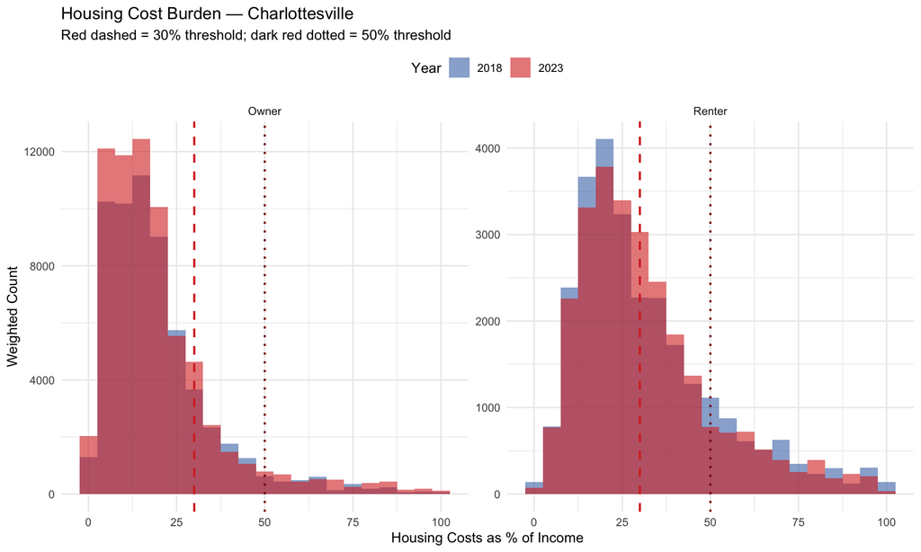

Distribution of housing cost burden for owners and renters in Charlottesville.

```r
bind_rows(
  bind_rows(cvl_h18, cvl_h23) %>%
    filter(!is.na(GRPIP), GRPIP > 0, TEN == 3) %>%
    mutate(burden_pct = GRPIP, tenure = "Renter"),
  bind_rows(cvl_h18, cvl_h23) %>%
    filter(!is.na(OCPIP), OCPIP > 0, TEN %in% c(1, 2)) %>%
    mutate(burden_pct = OCPIP, tenure = "Owner")
) %>%
  filter(burden_pct <= 100) %>%
  ggplot(aes(x = burden_pct, weight = WGTP, fill = factor(year))) +
  geom_histogram(binwidth = 5, position = "identity", alpha = 0.6) +
  geom_vline(xintercept = 30, linetype = "dashed", color = color_2023, linewidth = 0.8) +
  geom_vline(xintercept = 50, linetype = "dotted", color = "darkred", linewidth = 0.8) +
  facet_wrap(~tenure, scales = "free_y") +
  scale_fill_manual(values = c("2018" = color_2018, "2023" = color_2023), name = "Year") +
  labs(
    title = "Housing Cost Burden — Charlottesville",
    subtitle = "Red dashed = 30% threshold; dark red dotted = 50% threshold",
    x = "Housing Costs as % of Income", y = "Weighted Count"
  ) +
  theme_minimal() +
  theme(legend.position = "top")
```

### Monthly Rent

One of the most direct measures of housing affordability is how much renters pay each month. The following visualization compares gross monthly rent (including utilities) across the two time periods.

```r
renters <- cvl_hh_all %>%
  filter(TEN == 3, !is.na(GRNTP), GRNTP > 0)

median_rents <- renters %>%
  group_by(year) %>%
  summarise(median_rent = median(rep(GRNTP, WGTP), na.rm = TRUE))

kable(median_rents,
      col.names = c("Year", "Median Monthly Rent"),
      caption = "Median Gross Monthly Rent — Charlottesville")
```

Median Gross Monthly Rent — Charlottesville

| Year | Median Monthly Rent |
| --- | --- |
| 2018 | 1100 |
| 2023 | 1380 |

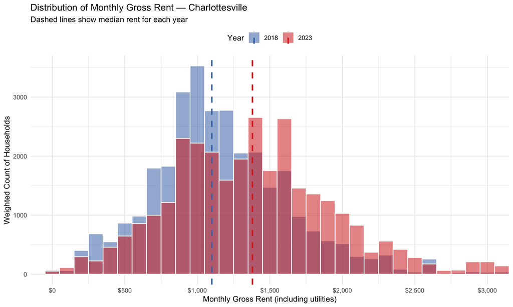

Distribution of monthly gross rent in Charlottesville, 2018 vs. 2023.

```r
ggplot(renters, aes(x = GRNTP, weight = WGTP, fill = factor(year))) +
  geom_histogram(binwidth = 100, position = "identity", alpha = 0.55, color = "white") +
  geom_vline(data = median_rents, aes(xintercept = median_rent, color = factor(year)),
             linetype = "dashed", linewidth = 1) +
  scale_fill_manual(values = c("2018" = color_2018, "2023" = color_2023), name = "Year") +
  scale_color_manual(values = c("2018" = color_2018, "2023" = color_2023), name = "Year") +
  scale_x_continuous(labels = dollar_format(), breaks = seq(0, 3000, 500)) +
  coord_cartesian(xlim = c(0, 3000)) +
  labs(
    title = "Distribution of Monthly Gross Rent — Charlottesville",
    subtitle = "Dashed lines show median rent for each year",
    x = "Monthly Gross Rent (including utilities)", y = "Weighted Count of Households"
  ) +
  theme_minimal() +
  theme(legend.position = "top")
```

The rightward shift in the 2023 distribution indicates rising rents, which directly impacts housing affordability for renters in Charlottesville.

### Tenure Composition

Whether someone rents or owns their home has major implications for housing stability and wealth accumulation. The following visualization shows how the balance of renters and owners has shifted over time.

```r
tenure_data <- cvl_hh_all %>%
  filter(!is.na(TEN)) %>%
  mutate(tenure = case_when(
    TEN == 1 ~ "Owner (with mortgage)",
    TEN == 2 ~ "Owner (no mortgage)",
    TEN == 3 ~ "Renter",
    TEN == 4 ~ "No rent paid",
    TRUE ~ "Other")) %>%
  group_by(year, tenure) %>%
  summarise(weighted_n = sum(WGTP, na.rm = TRUE), .groups = "drop") %>%
  group_by(year) %>%
  mutate(pct = weighted_n / sum(weighted_n) * 100) %>%
  ungroup()

kable(tenure_data %>% select(year, tenure, pct),
      digits = 1,
      col.names = c("Year", "Tenure Type", "% of Households"),
      caption = "Housing Tenure Composition — Charlottesville")
```

Housing Tenure Composition — Charlottesville

| Year | Tenure Type | % of Households |
| --- | --- | --- |
| 2018 | No rent paid | 3.0 |
| 2018 | Owner (no mortgage) | 23.4 |
| 2018 | Owner (with mortgage) | 41.3 |
| 2018 | Renter | 32.3 |
| 2023 | No rent paid | 2.5 |
| 2023 | Owner (no mortgage) | 23.9 |
| 2023 | Owner (with mortgage) | 43.8 |
| 2023 | Renter | 29.9 |

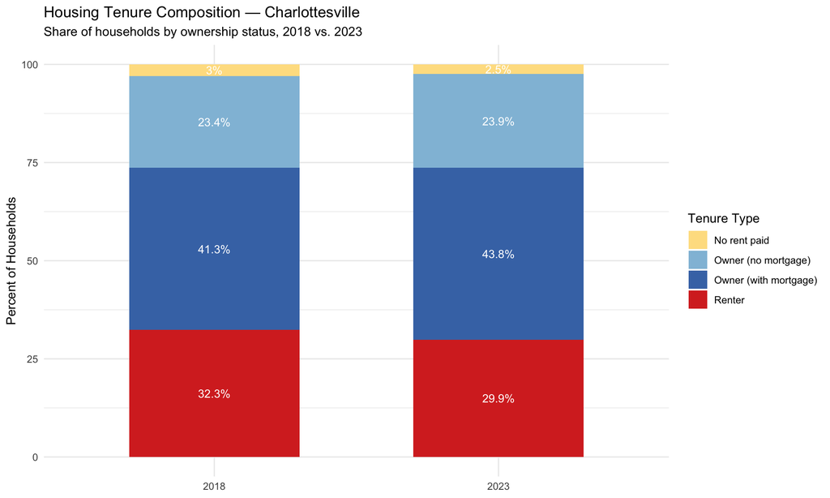

Housing tenure composition in Charlottesville, 2018 vs. 2023.

```r
ggplot(tenure_data, aes(x = factor(year), y = pct, fill = tenure)) +
  geom_col(position = "stack", width = 0.6) +
  geom_text(aes(label = paste0(round(pct, 1), "%")),
            position = position_stack(vjust = 0.5), size = 3.5, color = "white") +
  scale_fill_manual(values = c(
    "Owner (with mortgage)" = color_owner_mortgage,
    "Owner (no mortgage)"   = color_owner_free,
    "Renter"                = color_renter,
    "No rent paid"          = color_norent), name = "Tenure Type") +
  labs(
    title = "Housing Tenure Composition — Charlottesville",
    subtitle = "Share of households by ownership status, 2018 vs. 2023",
    x = NULL, y = "Percent of Households"
  ) +
  theme_minimal() +
  theme(legend.position = "right")
```

### Burden by Income

Housing cost burden does not affect all income groups equally. Lower-income households spend a far greater share of their income on housing, leaving fewer resources for other necessities.

```r
burden_by_income <- cvl_hh_all %>%
  filter(!is.na(HINCP), HINCP > 0) %>%
  mutate(
    burden_pct = case_when(
      TEN == 3 & !is.na(GRPIP) ~ GRPIP,
      TEN %in% c(1, 2) & !is.na(OCPIP) ~ OCPIP,
      TRUE ~ NA_real_),
    income_group = case_when(
      HINCP < 25000 ~ "Under $25K",
      HINCP < 50000 ~ "$25K–$50K",
      HINCP < 75000 ~ "$50K–$75K",
      HINCP < 100000 ~ "$75K–$100K",
      TRUE ~ "$100K+")) %>%
  filter(!is.na(burden_pct)) %>%
  mutate(income_group = factor(income_group,
                               levels = c("Under $25K", "$25K–$50K", "$50K–$75K",
                                           "$75K–$100K", "$100K+")))

burden_summary <- burden_by_income %>%
  group_by(year, income_group) %>%
  summarise(
    total = sum(WGTP, na.rm = TRUE),
    burdened = sum(WGTP[burden_pct >= 30], na.rm = TRUE),
    pct_burdened = burdened / total * 100,
    .groups = "drop")

kable(burden_summary %>% select(year, income_group, pct_burdened),
      digits = 1,
      col.names = c("Year", "Income Group", "% Cost Burdened"),
      caption = "Housing Cost Burden by Household Income — Charlottesville")
```

Housing Cost Burden by Household Income — Charlottesville

| Year | Income Group | % Cost Burdened |
| --- | --- | --- |
| 2018 | Under $25K | 81.0 |
| 2018 | $25K–$50K | 50.1 |
| 2018 | $50K–$75K | 24.3 |
| 2018 | $75K–$100K | 8.8 |
| 2018 | $100K+ | 2.3 |
| 2023 | Under $25K | 86.1 |
| 2023 | $25K–$50K | 53.7 |
| 2023 | $50K–$75K | 33.2 |
| 2023 | $75K–$100K | 11.9 |
| 2023 | $100K+ | 3.3 |

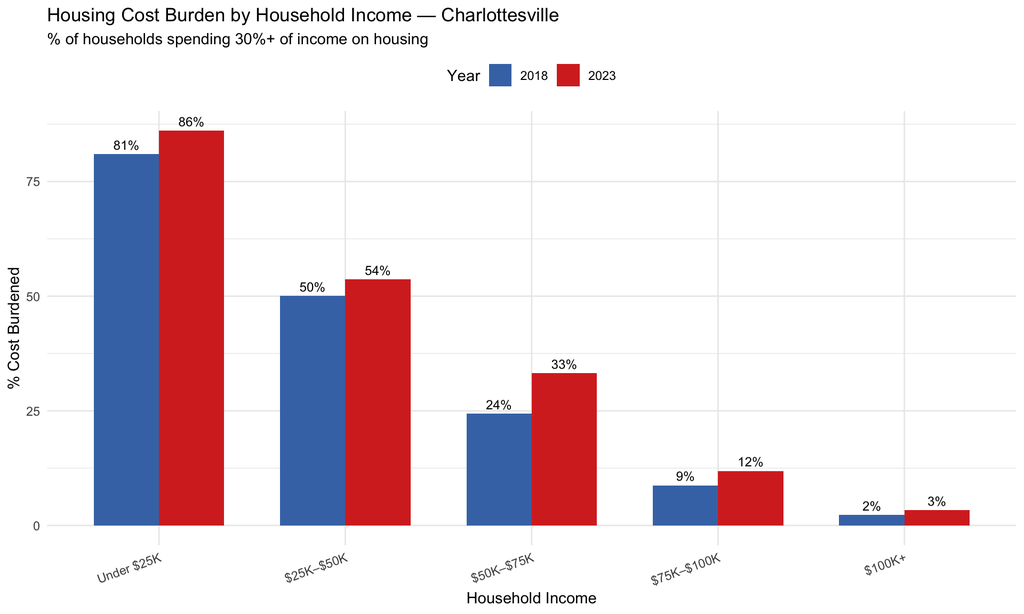

Housing cost burden by household income in Charlottesville.

```r
ggplot(burden_summary, aes(x = income_group, y = pct_burdened, fill = factor(year))) +
  geom_col(position = "dodge", width = 0.7) +
  geom_text(aes(label = paste0(round(pct_burdened, 0), "%")),
            position = position_dodge(width = 0.7), vjust = -0.5, size = 3.2) +
  scale_fill_manual(values = c("2018" = color_2018, "2023" = color_2023), name = "Year") +
  labs(
    title = "Housing Cost Burden by Household Income — Charlottesville",
    subtitle = "% of households spending 30%+ of income on housing",
    x = "Household Income", y = "% Cost Burdened"
  ) +
  theme_minimal() +
  theme(axis.text.x = element_text(angle = 20, hjust = 1), legend.position = "top")
```

Housing cost burden is concentrated among lower-income households and has worsened between 2018 and 2023 across all income brackets.

### Burden by Household Size

Households with more residents may share housing costs, while single-person households bear the full burden alone.

```r
size_burden <- cvl_hh_all %>%
  filter(!is.na(NP), NP > 0) %>%
  mutate(
    burden_pct = case_when(
      TEN == 3 & !is.na(GRPIP) ~ GRPIP,
      TEN %in% c(1, 2) & !is.na(OCPIP) ~ OCPIP,
      TRUE ~ NA_real_),
    hh_size = case_when(
      NP == 1 ~ "1 person",
      NP == 2 ~ "2 people",
      NP == 3 ~ "3 people",
      NP == 4 ~ "4 people",
      NP >= 5 ~ "5+ people")) %>%
  filter(!is.na(burden_pct)) %>%
  mutate(hh_size = factor(hh_size, levels = c("1 person", "2 people", "3 people", "4 people", "5+ people")))

size_burden_summary <- size_burden %>%
  group_by(year, hh_size) %>%
  summarise(
    total = sum(WGTP, na.rm = TRUE),
    burdened = sum(WGTP[burden_pct >= 30], na.rm = TRUE),
    pct_burdened = burdened / total * 100,
    .groups = "drop")

kable(size_burden_summary %>% select(year, hh_size, pct_burdened),
      digits = 1,
      col.names = c("Year", "Household Size", "% Cost Burdened"),
      caption = "Housing Cost Burden by Household Size — Charlottesville")
```

Housing Cost Burden by Household Size — Charlottesville

| Year | Household Size | % Cost Burdened |
| --- | --- | --- |
| 2018 | 1 person | 46.1 |
| 2018 | 2 people | 23.0 |
| 2018 | 3 people | 26.3 |
| 2018 | 4 people | 25.6 |
| 2018 | 5+ people | 24.8 |
| 2023 | 1 person | 49.7 |
| 2023 | 2 people | 21.3 |
| 2023 | 3 people | 19.5 |
| 2023 | 4 people | 20.8 |
| 2023 | 5+ people | 22.7 |

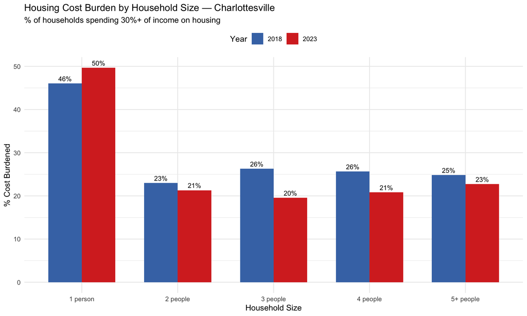

Housing cost burden by household size in Charlottesville.

```r
ggplot(size_burden_summary, aes(x = hh_size, y = pct_burdened, fill = factor(year))) +
  geom_col(position = "dodge", width = 0.7) +
  geom_text(aes(label = paste0(round(pct_burdened, 0), "%")),
            position = position_dodge(width = 0.7), vjust = -0.5, size = 3.2) +
  scale_fill_manual(values = c("2018" = color_2018, "2023" = color_2023), name = "Year") +
  labs(
    title = "Housing Cost Burden by Household Size — Charlottesville",
    subtitle = "% of households spending 30%+ of income on housing",
    x = "Household Size", y = "% Cost Burdened"
  ) +
  theme_minimal() +
  theme(legend.position = "top")
```

# 5. Limitations

Several limitations should be considered when interpreting the findings presented in this report.

First, the ACS PUMS data are based on survey samples rather than a complete census. Although survey weights are applied to produce population-representative estimates, the resulting figures are subject to sampling variability. For a small geographic area like Charlottesville, sample sizes for certain subgroups — particularly smaller racial or ethnic groups — may be relatively small, leading to estimates with wide margins of error. Throughout this analysis, groups with weighted totals below 500 are excluded to reduce the risk of reporting unreliable estimates, but even groups above this threshold may carry non-trivial uncertainty.

Second, the two ACS periods examined (2014–2018 and 2019–2023 five-year estimates) span the COVID-19 pandemic. The 2023 five-year estimates incorporate data collected during a period of significant economic disruption and recovery, which may influence observed changes in employment, income, and housing patterns. It is not possible from this analysis alone to distinguish between long-term structural trends and pandemic-related fluctuations.

Third, the definition of economic insecurity used here — living at or below 200% of the Federal Poverty Level — is a widely used threshold but is nonetheless an imperfect measure. The federal poverty line does not account for regional cost-of-living differences, and Charlottesville’s housing costs may render the 200% threshold insufficient for capturing all households experiencing material hardship. Alternative measures such as the Self-Sufficiency Standard or the Supplemental Poverty Measure could offer additional insight in future work.

Fourth, household-level and person-level data are analyzed somewhat separately in this report, with merging performed on SERIALNO. Not all person records can be perfectly matched to household records in the PUMS data, and the merged dataset may exclude some observations. Additionally, certain variables (such as SNAP participation) are recorded at the household level and do not capture within-household variation in access or benefit.

Finally, this analysis is descriptive rather than causal. While the patterns documented here are informative, they do not establish causal relationships between demographic characteristics and economic insecurity. Observed disparities may reflect the influence of unmeasured confounders, institutional factors, or historical patterns that are not captured in the ACS data alone.

# 6. Conclusion

The findings from this analysis reveal that economic insecurity in Charlottesville is both persistent and unevenly distributed. While the overall poverty rate in Charlottesville may appear comparable to or only slightly above the statewide average, the data show that a substantial share of the population lives at or near the poverty threshold, and several demographic and structural patterns emerge clearly.

Racial disparities in poverty and economic insecurity are pronounced: Black and African American residents experience poverty at rates significantly higher than their White counterparts, a pattern consistent with national trends but one that takes on particular significance in a small city context. Young adults — many of whom are university students — also exhibit high rates of economic insecurity, though their circumstances may differ from those of families with children or older adults on fixed incomes.

Housing emerges as a central driver of economic vulnerability. A large share of Charlottesville households are renters, and rents have risen noticeably between 2018 and 2023. Housing cost burden rates are highest among the lowest-income households and among individuals living alone, and the burden has worsened over the five-year period. These findings suggest that housing affordability is not only a quality-of-life concern but a fundamental component of economic insecurity in the region.

Employment patterns paint a more nuanced picture. While civilian employment rates are lower among those in poverty, a notable share of economically insecure individuals are employed, suggesting the presence of low-wage work and underemployment. Average weekly hours among workers in poverty are lower than among those above the poverty line, further indicating that insufficient work hours may contribute to economic hardship alongside low wages.

Health insurance coverage has improved — likely reflecting Virginia’s Medicaid expansion — but gaps remain, particularly among those in the lowest poverty bands. Public assistance receipt, while concentrated among those in poverty, reaches only a fraction of the economically insecure population, raising questions about program accessibility and awareness.

Taken together, these findings underscore the multi-dimensional nature of economic insecurity. Poverty in Charlottesville is not merely an income problem; it reflects intersecting challenges in housing, employment, healthcare access, and demographic inequality.

# 7. Next Steps

Building on the descriptive foundation laid by this report, several avenues for further research and policy analysis merit exploration.

First, incorporating the ACS Supplemental Poverty Measure or a regional Self-Sufficiency Standard would provide a more nuanced assessment of economic insecurity that accounts for Charlottesville’s relatively high cost of living — particularly in housing.

Second, a more granular analysis of the university student population would help disentangle temporary low-income status (common among students) from longer-term economic vulnerability experienced by permanent residents. Filtering by enrollment status and age could sharpen estimates of the “true” poverty population.

Third, spatial analysis using PUMA-level data or geocoded estimates could identify neighborhoods within or near Charlottesville where economic insecurity is most concentrated, supporting more targeted interventions.

Fourth, longitudinal tracking of the same indicators over additional ACS periods would clarify whether the changes observed between 2018 and 2023 represent durable trends or pandemic-era anomalies.

Fifth, investigating the relationship between housing cost burden and other dimensions of insecurity — such as food insecurity (SNAP participation), health outcomes, and educational attainment — could illuminate how housing stress cascades into broader material hardship.

Finally, qualitative research — interviews, focus groups, or case studies with economically insecure residents — would complement the quantitative portrait presented here and surface the lived experiences, coping strategies, and barriers that survey data alone cannot capture.

# 8. References

Charlottesville Low-Income Housing Coalition. (2020, February). The impact of racism on affordable housing in Charlottesville. Link: https://www.justice4all.org/wp-content/uploads/2020/03/Housing-Report-FINAL.pdf Relevance: This report looks at the historical and structural roots of housing inequality in Charlottesville, especially things like segregation, displacement, and policy decisions that still affect current outcomes. It helps explain why the patterns we see in sources like the Orange Dot Report exist, rather than just describing them, which makes it really useful for interpreting our data and connecting it to long-term causes.

Colburn, G., Walter, R. J., & DeLuca, S. (2024). The dynamics of housing cost burden among renters in the United States. https://pmc.ncbi.nlm.nih.gov/articles/PMC12333583/ Relevance: This paper examines how housing cost burden—defined as spending more than 30% of income on rent—has changed over time in the United States, with a focus on whether it is temporary or persistent. The authors focus on two main questions: 1) how much of the increase in housing cost burden is driven by how often households enter, exit, and reenter this state, and 2) how these dynamics differ across race and socioeconomic status.

Hanes, J. (2018, November 28). YOU Issue: Charlottesville leads in income inequality. C-VILLE Weekly. https://c-ville.com/income-inequality/ Relevance: This is a more community-oriented article that helps explain income inequality in Charlottesville in a way that’s easier to connect to real-world dynamics. It also references Hamilton Lombard from the UVA Weldon Cooper Center, which adds credibility and gives more insight into structural drivers (like demographic and economic trends) that could be influencing what we see in our data.

Joint Center for Housing Studies of Harvard University. (2023). The state of the nation’s housing 2023. https://www.jchs.harvard.edu/state-nations-housing-2023 Relevance: This report discusses housing affordability in the United States, specifically in terms of the relationship between the cost of housing and household incomes and the groups most prone to cost burden. Instead of having a single formal research question, it concentrates on recording the process and the reasons of the housing burden cost rise, especially its variations among income levels and occupations in the labor market.

Langston, A. (2018). 100 Million and Counting: A Portrait of Economic Insecurity in the United States. PolicyLink. https://www.policylink.org/sites/plorg/files/2025-08/100_million_and_counting_FINAL.pdf Relevance: This report examines economic insecurity at the national level, defining the economically insecure as people living in households below 200% of the federal poverty level. It argues that hardship is far more widespread and more unevenly distributed than conventional poverty measures suggest. Our project adopts the report’s threshold and applies it to our own region.

Mathon, S. (2026, February 4). In 20 years, Sunshine Mathon hopes that entrenched income inequality in central Virginia will be a thing of the past. Charlottesville Tomorrow. https://www.cvilletomorrow.org/in-20-years-sunshine-mathon-hopes-that-entrenched-income- inequality-in-central-virginia-will-be-a-thing-of-the-past/ Relevance: This article details the lived experience of its author, a local nonprofit leader named Sunshine Mathon who grew up experiencing housing instability, and the efforts made by the local affordable housing nonprofit in Charlottesville that he now leads – the Piedmont Housing Alliance. The nonprofit’s purpose is to promote the construction of affordable housing through partnerships with the City of Charlottesville, Community Development Financial Institutions, and other nonprofit organizations. One of their flagship projects includes their Kindlewood project centered around the reconstruction of apartment complex buildings, a project aimed at easing access to affordable housing for low income families.

Mitchell, E., Claibourn, M., & Schuyler, R. (2024). Orange Dot Report 6.0: Family Self-Sufficiency in the Charlottesville Region: Albemarle, Buckingham, Fluvanna, Greene, Louisa, Nelson Counties & the City of Charlottesville, Virginia. Center for Community Partnerships. https://communitypartnerships.virginia.edu/sites/default/files/2024-10/orange-dot-6-final-2024.pdf Relevance: This report explores how many families in the Charlottesville region earn too little to meet their basic needs, interrogating variation across characteristics like locality and race. It challenges the notion that official poverty thresholds suffice for understanding hardship in Charlottesville. Rather than simply determining who falls below the federal poverty line and leaving it at that, the report digs more deeply into who in the region is actually unable to cover the cost of basic necessities.

UVA President’s Council on UVA–Community Partnerships. (2024). Affordable housing metrics. University of Virginia. https://prescouncil.president.virginia.edu/affordable-housing-metrics Relevance: This source builds directly off the Orange Dot Report and connects the data to actual policy goals and housing initiatives in Charlottesville. It helps bridge the gap between just identifying inequality and understanding what’s being done about it, which is useful for thinking about the implications of our findings and potential solutions.

Virginia Department of Housing &andommunity Development. (2022). Economic trends (Chapter 13). In HB854 statewide housing study: Current efforts, future needs, new strategies. https://dmz1.dhcd.virginia.gov/HB854/part-3-economic.html Relevance: This report gives broader economic context—like employment and income trends across Virginia and the region—which helps us better understand how Charlottesville fits into larger patterns of inequality. Even though the data only goes up to 2020, that can actually be useful since it lets us look at trends before the shock of COVID and compare them to what we might be seeing now.